# M2 Midterm II

Data Visualization (STAT 302)

Martha Eichlersmith

2020-05-17

## Datasets

We will be using the `NH_2016pp_dem.txt` and `NH_2016pp_rep.txt` datasets. `NH_2016pp_dem.txt` contains the raw vote count by county for each candidate for the 2016 New Hampshire Democratic presidential primary. `NH_2016pp_rep.txt` contains the raw vote count by county for each candidate for the 2016 New Hampshire Republican presidential primary.

```r
# Load package(s)
library(tidyverse)
library(sf)

# Read in the dataset(s)
dem <- read_delim(file = "data/NH_2016pp_dem.txt", delim = "|") %>%
  janitor::clean_names()
rep <- read_delim(file = "data/NH_2016pp_rep.txt", delim = "|") %>%
  janitor::clean_names()
```

## Exercises

Complete the following exercises.

### Exercise 1

Using the `NH_2016pp_dem.txt` and `NH_2016pp_rep.txt` datasets in conjunction with mapping data from the `maps` package replicate, as close as possible, the graphic below. Note the graphic is comprised of two plots displayed side-by-side. The plots both use the same shading scheme (i.e. scale limits and fill options). *Hint: You will have to use `pivot_longer()`, `left_join()`, and other data manipulation functions.*

**Background Information:** On Tuesday, February 9th 2016, New Hampshire held primaries for the Democratic and Republican Parties to apportion state delegates to nominate their respective party’s presidential nominee. Bernie Sanders (D) and Donald Trump (R) had very good nights. They both won every county in New Hampshire within their respective party’s primary. In the Democratic primary, Hillary Clinton was second in each county. In the Republican primary John Kasich was second in all but one county where he was in a virtual tie for second, but technically in third (thus the asterisk). The graphic below visualizes the ratio of the candidate with the highest vote total to the candidate with the second highest vote total in each county (a measure of strength for each county winner). The fact that we can replace first and second place with candidate names is simply a byproduct of how the primaries played out. Otherwise, the legend labels should have been “First to Second Ratio” or we might have implemented an alternative shading scheme.

After replicating the graphic provide a summary of how the two primaries relate to one another.

```r
# Setup NH map dataset
nh_dat <- maps::map(
  database = "county",
  regions = "new hampshire",
  plot = FALSE,
  fill = TRUE
) %>%
  #convert data into sf object (simple features)
  st_as_sf() %>%
  # remove state name, so that county name is only thing remaining
  mutate(ID = str_remove(ID, ".*,")) %>%
  # rename column to county
  rename(county = ID)

#check the coord reference system
#sf::st_crs(nh_dat)
```

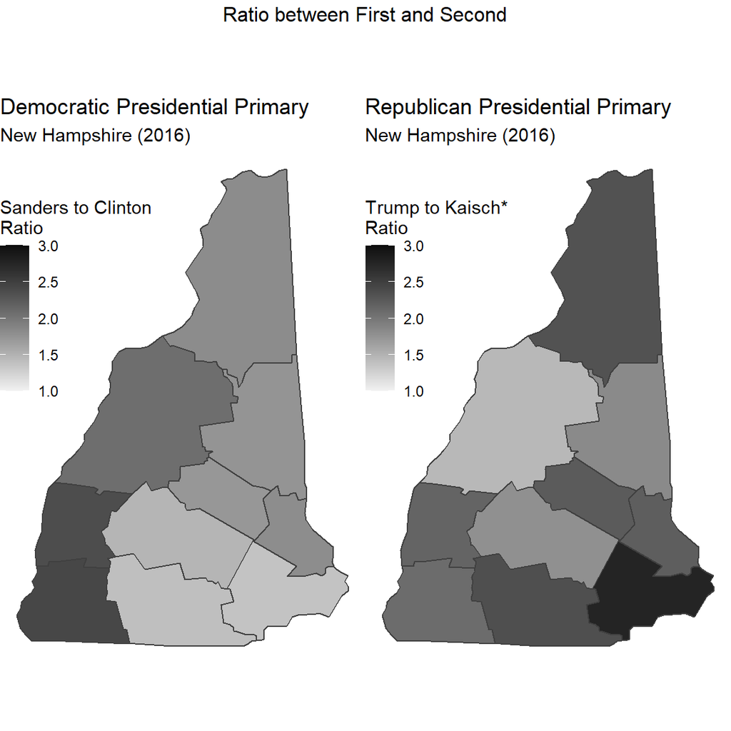

```r
#looking at just rato of top 2
nh_plot1 <- function(df, ratio_name, party_name){
df %>%
  pivot_longer(col = -county, names_to = "candidate", values_to = "votes") %>%
  group_by(county) %>%
  summarise(
    ratio = max(votes) / nth(votes, n = 2, order_by = desc(votes))
  ) %>%
  left_join(., nh_dat, by = "county") %>%
ggplot() +
  geom_sf(
      aes(geometry = geom, fill = ratio)
    , color = "grey25"
  ) +
  scale_fill_gradient(
      name = paste(ratio_name, "Ratio", sep="\n")
    , limits = c(1, 3)
    , breaks = c(seq(1, 3, 0.5))
    , low = "grey95"
    , high = "grey5"
  ) +
  theme_void() +
  labs(
      title = paste(party_name, "Presidential Primary")
    , subtitle = "New Hampshire (2016)"
  ) +
  theme(
      legend.position = c(0, .90)
    , legend.justification = c(0, 1)
    , legend.background = element_rect(fill = NA, color =NA)
  )
}

p1 <- nh_plot1(dem, "Sanders to Clinton", "Democratic")
p2 <- nh_plot1(rep, "Trump to Kaisch*", "Republican")
gridExtra::grid.arrange(p1, p2, ncol = 2, top = "Ratio between First and Second")
```

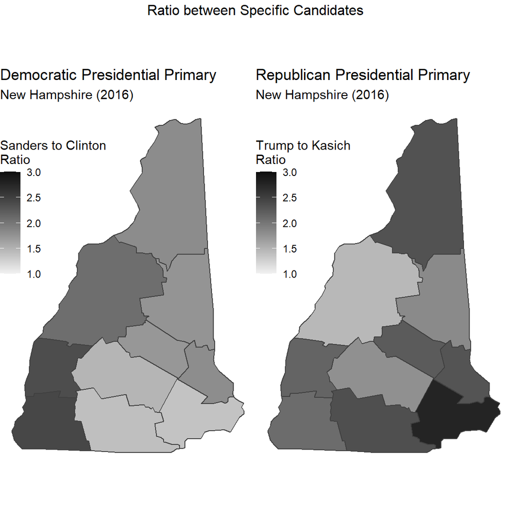

```r
#look at 2 specific people ratio
votes  <- left_join(dem, rep, "county")
nh_primary <- left_join(votes, nh_dat, by = "county")

nh_plot2 <- function(map_df, name1, name2, ratio_name, party){
map_df %>%
  mutate(ratio = map_df[[name1]]/map_df[[name2]]) %>%
ggplot() +
  geom_sf(
      aes(geometry = geom, fill = ratio)
    , color = "grey25"
  ) +
  scale_fill_gradient(
      name = paste(ratio_name, "Ratio", sep="\n")
    , limits = c(1, 3)
    , breaks = c(seq(1, 3, 0.5))
    , low = "grey95"
    , high = "grey5"
  ) +
  theme_void() +
  labs(
      title = paste(party, "Presidential Primary")
    , subtitle = "New Hampshire (2016)"
  ) +
  theme(
      legend.position = c(0, .90)
    , legend.justification = c(0, 1)
    , legend.background = element_rect(fill = NA, color =NA)
  )
}

p1 <- nh_plot2(nh_primary, "sanders", "clinton", "Sanders to Clinton", "Democratic")
# ast not needed because looking at Trump:Kasich at each county
p2 <- nh_plot2(nh_primary, "trump", "kasich", "Trump to Kasich", "Republican")

gridExtra::grid.arrange(p1, p2, ncol = 2, top = "Ratio between Specific Candidates")
```

```r
votes %>%
  mutate(
      ratio_rep = trump/kasich
    , ratio_dem = sanders/clinton
         ) %>%
  select(county, ratio_rep, ratio_dem)
```

```
## # A tibble: 10 x 3
##    county       ratio_rep ratio_dem
##    <chr>            <dbl>     <dbl>
##  1 belknap           2.24      1.72
##  2 carroll           1.83      1.75
##  3 cheshire          2.08      2.43
##  4 coos              2.32      1.81
##  5 grafton           1.45      2.07
##  6 hillsborough      2.34      1.39
##  7 merrimack         1.77      1.48
##  8 rockingham        2.77      1.36
##  9 strafford         2.30      1.80
## 10 sullivan          2.16      2.37
```

There is a larger margin of victory in the democratic primary in the bottom left county, and a larger margin of victory in the Rebulican primary in the bottom right hand sign. This could mean that in these two counties there is very strong support for the lead candiate in the repsective parties. For example, Rockingham has a very high Trump to Kasich ratio but the smallest Sanders to Clinton ratio. This could mean that Republicans are Rockingham is very pro-Trump and in agreement; but the Democrats in this county do not have a consensus on a democratic candidate - is this because the county is so pro-Trump and more conservative?

### Exercise 2

Create a fake/randomly generated dataset to approximate a scatterplot graphic shown.

```r
set.seed(2468)
low_x <- rnorm(20, mean = 5,  sd = 2)
med_x <- rnorm(20, mean = 10, sd = 2)
hig_x <- rnorm(20, mean = 15, sd = 2)

low_y <- low_x + rnorm(20, mean = 0, sd = 1)
med_y <- med_x + rnorm(20, mean = 0, sd = 2)
hig_y <- hig_x + rnorm(20, mean = 0, sd = 3)

df <- tibble(
    x = c(low_x, med_x, hig_x)
  , y = c(low_y, med_y, hig_y)
  , Group = c(
      rep("Low", 20)
    , rep("Medium", 20)
    , rep("High", 20)
  )
) %>%
  mutate(Group = factor(Group, levels = c("High", "Medium", "Low")))
```

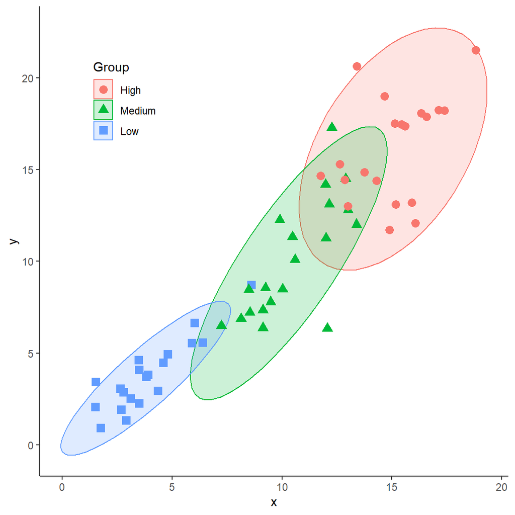

```r
ggplot(df, aes(x, y, color = Group, shape = Group, fill = Group)) +
  stat_ellipse(geom = "polygon", alpha = 0.2) +
  geom_point(size = 3) +
  scale_shape_manual(values = c(16, 17, 15)) +
  theme_classic() +
  scale_x_continuous(breaks = seq(0, 20, 5)) +
  scale_y_continuous(breaks = seq(0, 20, 5)) +
  theme(legend.position = c(0.1, 0.9), legend.justification = c(0, 1) )
```

### Exercise 3

Create a data set and a graphic based on `tile`’s for each `x` and `y` value.

- The **function** can be drawn using the equation provided on the graphic. The color of the **function** is a 50-50 mix of red and blue.

```r
base_seq <- seq(-1, 1, 0.01)
n_seq <- length(base_seq)


x <- rep(base_seq, n_seq)
y <- sort(rep(base_seq, n_seq))

cubic_df <- tibble(x, y) %>%
  mutate( fill_amount = x^3 - y)
```

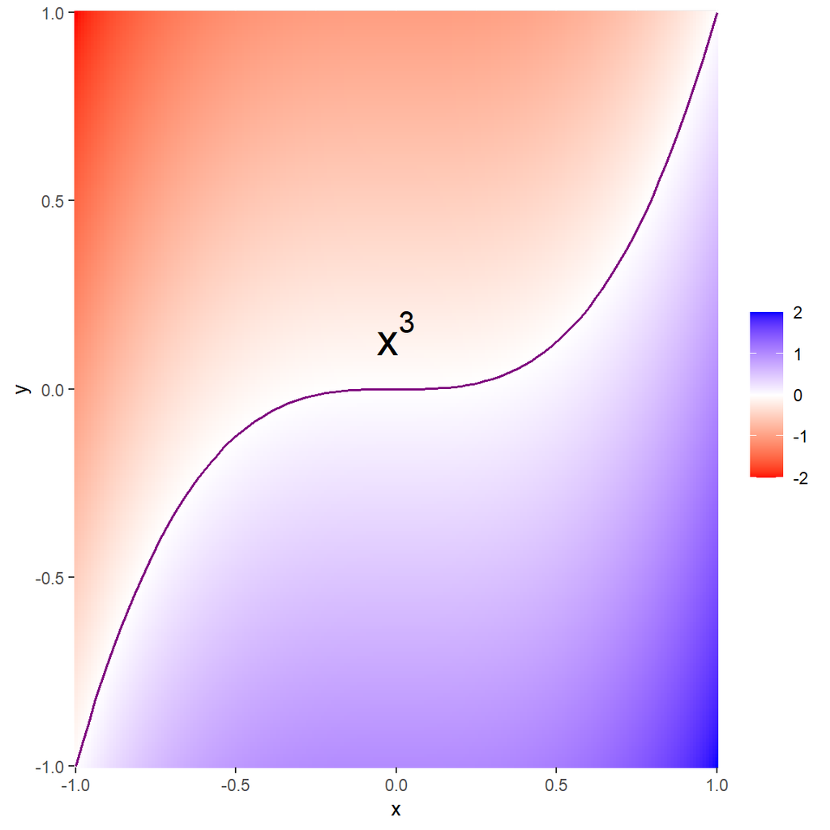

```r
func_cube <- function(x){x^3}

ggplot(cubic_df, aes(x, y, fill = fill_amount)) +
  geom_raster() +
  scale_fill_gradient2(
      name = NULL
    , high = "blue"
    , low = "red"
    , mid = "white"
    , midpoint = 0
  ) +
  scale_x_continuous(expand = c(0, 0)) +
  scale_y_continuous(expand = c(0, 0)) +
  stat_function(
      fun = func_cube
    , color = rgb(.5*255, 0, .5*255, maxColorValue = 255)
    , size = 0.6
  ) +
  annotate(
    "text"
    , x = 0
    , y = 0.15
    , label = "x^3"
    , parse = TRUE
    , size = 8
  )
```